# Covid-19-Oster-Spezial

Proseminar “Text as Data”, FS20

[Ueli Reber](https://uelireber.ch), Institut für Kommunikations- und Medienwissenschaft, Universität Bern

Version vom 13. April 2020

## Idee

Die Online-Medien auf der ganzen Welt sind derzeit voll mit Grafiken zur Covid-19-Pandemie. Auch in Schweizer Medien finden sich entsprechende Beiträge, unter anderem bei [SRF](https://www.srf.ch/news/international/schweiz-und-weltweit-so-entwickeln-sich-die-coronavirus-fallzahlen), dem [Bund (TX Group)](https://interaktiv.derbund.ch/2020/covid-19-ausbruch-im-vergleich/), der [NZZ](https://www.nzz.ch/panorama/die-wichtigsten-grafiken-zum-coronavirus-ld.1542774) oder [Watson](https://www.watson.ch/schweiz/daten/321158876-coronavirus-in-der-schweiz-die-aktuellen-entwicklungen-in-den-kantonen). Grund genug, dass auch wir uns mal mit den Zahlen beschäftigen, ein paar schöne Grafiken produzieren und dabei unsere frisch erworbenen R-Kenntnisse an der Wirklichkeit testen.

## Daten

Für aussagekräftige Grafiken braucht es natürlich gute Daten. Nachdem die Datenqualität in der Schweiz vor allem zu Beginn der Krise problematisch war (vgl. Beitrag in der [Republik](https://www.republik.ch/2020/03/20/die-zahl-der-todesfaelle-haben-wir-aus-wikipedia-entnommen)), hat sich nun das [Statistische Amt des Kantons Zürich](https://statistik.zh.ch/internet/justiz_inneres/statistik/de/covid19.html) als zuverlässige Quelle etabliert. Die Zürcher Statistiker*innen sammeln Daten aus allen Kantonen (und dem Fürstentum Liechtenstein) und stellen sie über eine Schnittstelle allen interessierten Personen für Auswertungen zur Verfügung. Wie ein Blick in die oben erwähnten Beiträge zeigt, arbeiten auch die meisten Schweizer Online-Medien mit den Zürcher Daten.

Mit Hilfe ein paar weniger tidyverse-Funktionen, können wir uns das täglich aktualisierte CSV-File einfach aus dem Web ziehen.

```r
# Package laden
library(tidyverse)
```

```r
# Covid-19-Daten des Statistischen Amts des Kantons Zürich importieren
path <- "https://raw.githubusercontent.com/openZH/covid_19/master/COVID19_Fallzahlen_CH_total_v2.csv"
covid_19_raw <- read_csv(url(path))
```

```r
# Blick in die Daten werfen
glimpse(covid_19_raw)
```

```
## Observations: 868
## Variables: 12
## $ date                       <date> 2020-02-25, 2020-02-25, 2020-02-26, …
## $ time                       <drtn>       NA,       NA,       NA,       …
## $ abbreviation_canton_and_fl <chr> "GE", "TI", "GE", "TI", "FL", "GE", "…
## $ ncumul_tested              <dbl> 72, NA, 178, NA, 3, 326, NA, NA, NA, …
## $ ncumul_conf                <dbl> 0, 1, 1, NA, NA, 1, NA, 1, 1, 1, 1, 3…
## $ new_hosp                   <dbl> NA, NA, NA, NA, NA, NA, NA, NA, NA, N…
## $ current_hosp               <dbl> 0, NA, 1, NA, NA, 1, NA, NA, NA, NA, …
## $ current_icu                <dbl> 0, NA, 0, NA, NA, 0, NA, NA, NA, NA, …
## $ current_vent               <dbl> 0, NA, 0, NA, NA, 0, NA, NA, NA, NA, …
## $ ncumul_released            <dbl> NA, NA, NA, NA, NA, NA, NA, NA, NA, N…
## $ ncumul_deceased            <dbl> NA, NA, NA, NA, NA, NA, NA, NA, NA, N…
## $ source                     <chr> "https://www.ge.ch/document/covid-19-…
```

Ein Beschrieb der verschiedenen Variablen findest du [hier](https://github.com/openZH/covid_19#data-structure). Der Data Frame enthält Informationen wie die Anzahl getesteter Personen (`ncumul_tested`), Anzahl bestätigter Fälle (`ncumul_conf`), Anzahl aktuell hospitalisierter Personen (`current_hosp`). Die Daten sind aufgeschlüsselt nach Tag und Kanton (tidy!).

## Plots

### Fallentwicklung in der Schweiz

Schauen wir uns zuerst die Fallentwicklung, also die kumulierte Anzahl positiv getesteter, verstorbener sowie genesener oder aus dem Spital entlassener Personen über die Zeit für die gesamte Schweiz an. Für die Betrachtung von Zeitreihen bietet sich ein Liniendiagramm an. Die benötigten Informationen finden wir in den Spalten `date`, `ncumul_conf`, `ncumul_deceased`, `ncumul_released`.

```r
# Rohdaten in die richtige Form bringen und aggregieren
cumul_cases_time <- covid_19_raw %>%
  # Relevante Spalten auswählen
  select(date, ncumul_conf, ncumul_deceased, ncumul_released) %>%
  # Vom Wide- ins Long-Format bringen
  gather(key = "type", value = "cases", -date) %>%
  # Gruppieren nach Datum und Typ
  group_by(date, type) %>%
  # Fälle aggregieren (NA ignorieren)
  summarise(cases = sum(cases, na.rm = TRUE))

head(cumul_cases_time)
```

```
## # A tibble: 6 x 3
## # Groups:   date [2]
##   date       type            cases
##   <date>     <chr>           <dbl>
## 1 2020-02-25 ncumul_conf         1
## 2 2020-02-25 ncumul_deceased     0
## 3 2020-02-25 ncumul_released     0
## 4 2020-02-26 ncumul_conf         1
## 5 2020-02-26 ncumul_deceased     0
## 6 2020-02-26 ncumul_released     0
```

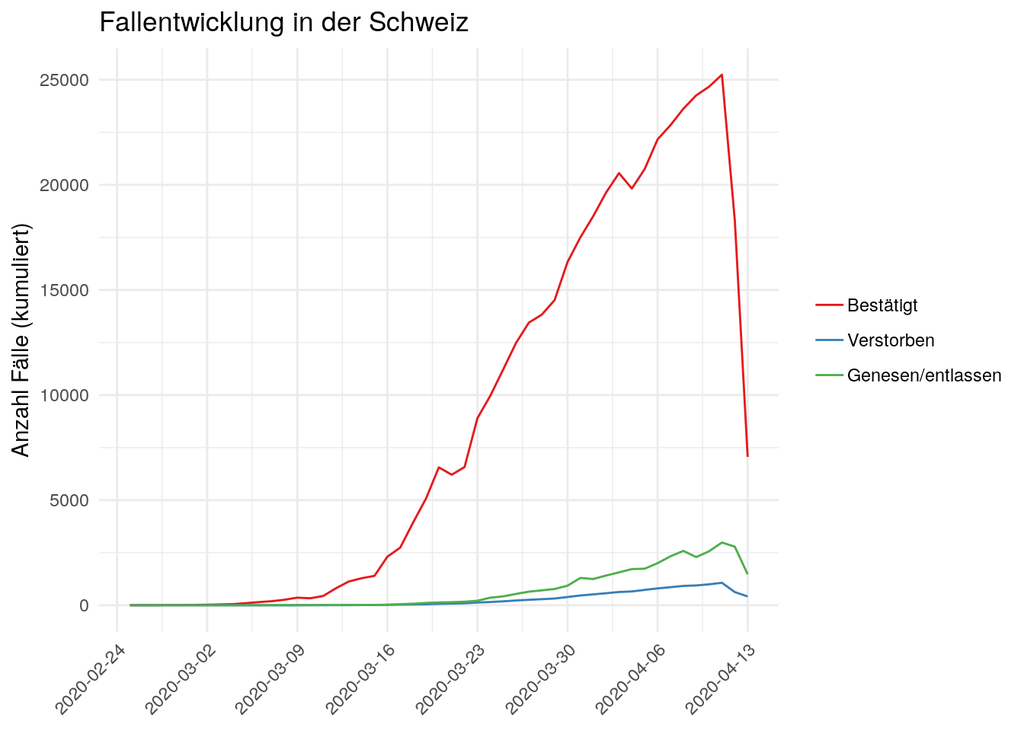

```r
# Liniendiagramm plotten
ggplot(data = cumul_cases_time) +
  # Liniendiagramm definieren
  geom_line(mapping = aes(x = date, y = cases, color = type)) +
  # Theme auswählen
  theme_minimal() +
  # Kein Titel auf der X-Achse
  # Kein Titel bei der Legende
  # Beschriftung der X-Achse um 45° drehen
  theme(axis.title.x = element_blank(),
        legend.title = element_blank(),
        axis.text.x = element_text(angle = 45, hjust = 1, vjust = 1)) +
  # Titel und Beschriftung der Y-Achsen anpassen
  labs(title = "Fallentwicklung in der Schweiz", y = "Anzahl Fälle (kumuliert)") +
  # Linienfarbe und Beschriftung anpassen
  scale_colour_brewer(palette = "Set1", labels = c("Bestätigt", "Verstorben", "Genesen/entlassen")) +
  # Wochen auf X-Achse kennzeichnen
  scale_x_date(date_breaks = '1 week')
```

Dieser Plot zeigt, wie schnell sich das Virus in der Bevölkerung ausgebreitet hat, beziehungsweise nach wie vor ausbreitet. Zudem sehen wir, dass die Daten nicht ganz fehlerfrei sind (insb. sind die letzten Tage noch nicht vollständig erfasst). Kumulierten Daten dürften eigentlich keine Dellen haben, da die Anzahl Fälle immer mindestens derjenigen des Vortages entsprechen muss. Wir könnten das ausbügeln, indem wir den Wert am Tag $t$ durch den am Tag $t-1$ ersetzen, sollte dieser grösser sein. Da dies aber einfacher gesagt als getan ist, lassen wir es an dieser Stelle bei der Einsicht bewenden und schauen grosszügig über die Dellen in unseren Kurven hinweg.

### Neuinfektionen

Schauen wir uns lieber die täglich neu gemeldeten Fälle an. Leider können wir die Zahlen dafür nicht einfach aus dem File des Statistischen Amtes nehmen, sondern müssen sie selbst aus den Werten in `ncumul_conf` berechnen. Auch diese Aufgabe ist nicht ganz einfach zu lösen. Wir probieren es im Folgenden mit einem `for`-Loop, der in jedem Durchgang den Wert für einen Tag berechnet und dem Data Frame `new_cases` als Zeile hinzufügt. Andere Vorgehen sind auch möglich (und vielleicht sogar eleganter).

Beachte, dass die festgestellen Dellen zu negativen Werten führen. Da es aber nicht weniger als Null neue Fälle pro Tag geben kann, ersetzten wir mittels `ifelse`-Anweisung alle negativen Werte, durch `0`.

```r
# Neue Fälle am ersten Tag (25.2.2020)
day_1 <- min(covid_19_raw$date)
new_cases <- covid_19_raw %>%
  # Relevante Spalten auswählen
  select(date, ncumul_conf) %>%
  # Nach Tag 1 filtern
  filter(date == day_1) %>%
  # Nach Datum gruppieren (Tag 1)
  group_by(date) %>%
  # Fälle aggregieren (NA ignorieren)
  summarise(new_cases = sum(ncumul_conf, na.rm = TRUE))

# Neue Fälle an den weiteren Tagen
for (x in 2:length(unique(covid_19_raw$date))) {
  # Relevante Tage definieren (Tag x, 1 Tag vor X)
  day_x <- as.character(unique(covid_19_raw$date)[x])
  day_bef_x <- as.character(unique(covid_19_raw$date)[x - 1])
  # Neue Fälle für Tag x berechnen
  new_cases <- covid_19_raw %>%
    select(date, ncumul_conf) %>%
    filter(date == day_x | date == day_bef_x) %>%
    group_by(date) %>%
    summarise(ncumul_cases = sum(ncumul_conf, na.rm = TRUE)) %>%
    # Tag x und Tag vor x zu Spalten machen
    spread(date, ncumul_cases) %>%
    # Anzahl neue Fälle berechnen (0 wenn Wert negativ)
   # Code ist etwas umständlich, da für Strings (day_x) die Krücke .data[[string]] verwendet werden muss
    mutate(new_cases = ifelse(.data[[day_x]] - .data[[day_bef_x]] >= 0, .data[[day_x]] - .data[[day_bef_x]], 0)) %>%
    # Spalte mit Datum herstellen
    mutate(date = as.Date(day_x)) %>%
    # Relevante Spalten auswählen
    select(date, new_cases) %>%
    # Neue Fälle von Tag x mit Fällen von anderen Tagen kombinieren
    bind_rows(new_cases) %>%
    # Aufsteigend sortieren (nach Datum)
    arrange(date)
}

head(new_cases)
```

```
## # A tibble: 6 x 2
##   date       new_cases
##   <date>         <dbl>
## 1 2020-02-25         1
## 2 2020-02-26         0
## 3 2020-02-27         2
## 4 2020-02-28         7
## 5 2020-02-29         0
## 6 2020-03-01         7
```

Nun können wir die neuen Fällen pro Tag als Balkendiagramm darstellen.

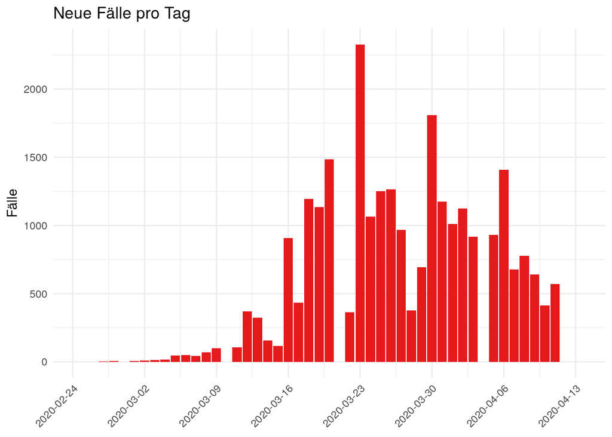

```r
# Balkendiagramm plotten
ggplot(data = new_cases) +
  # Balkendiagramm definieren
  geom_bar(mapping = aes(x = date, y = new_cases),
           stat = "identity", fill = "#e41a1c") +
  # Theme auswählen
  theme_minimal() +
  # Kein Titel auf der X-Achse
  # Beschriftung der X-Achse um 45° drehen
  theme(axis.title.x = element_blank(),
        axis.text.x = element_text(angle = 45, hjust = 1, vjust = 1)) +
  # Titel und Beschriftung der Y-Achsen anpassen
  labs(title = "Neue Fälle pro Tag", y = "Fälle") +
  # Wochen auf X-Achse kennzeichnen
  scale_x_date(date_breaks = '1 week')
```

Wir sehen, dass die ergriffenen Massnahmen greifen und die Neuinfektionen rückläufig sind. Oder wie Daniel Koch sagte: “Wir sind über den Berg, falls es der letzte Berg ist” ([SRF](https://www.srf.ch/news/schweiz/corona-krise-in-der-schweiz-wir-sind-ueber-den-berg-falls-es-der-letzte-berg-ist)). Gute Neuigkeiten!

### Todesfälle

Schauen wir uns aber auch noch die weniger guten Neuigkeiten an, nämlich die Entwicklung der Todesfälle pro Tag. Das Vorgehen ist dabei genau gleich wie bei den Neuinfektionen.

```r
# Todesfälle am ersten Tag (25.2.2020)
day_1 <- min(covid_19_raw$date)
new_deceased <- covid_19_raw %>%
  # Relevante Spalten auswählen
  select(date, ncumul_deceased) %>%
  # Nach Tag 1 filtern
  filter(date == day_1) %>%
  # Nach Datum gruppieren (Tag 1)
  group_by(date) %>%
  # Fälle aggregieren (NA ignorieren)
  summarise(new_deceased = sum(ncumul_deceased, na.rm = TRUE))

# Todesfälle an den weiteren Tagen
for (x in 2:length(unique(covid_19_raw$date))) {
  # Relevante Tage definieren (Tag x, 1 Tag vor X)
  day_x <- as.character(unique(covid_19_raw$date)[x])
  day_bef_x <- as.character(unique(covid_19_raw$date)[x - 1])
  # Todesfälle für Tag x berechnen
  new_deceased <- covid_19_raw %>%
    select(date, ncumul_deceased) %>%
    filter(date == day_x | date == day_bef_x) %>%
    group_by(date) %>%
    summarise(ncumul_deceased = sum(ncumul_deceased, na.rm = TRUE)) %>%
    # Tag x und Tag vor x zu Spalten machen
    spread(date, ncumul_deceased) %>%
    # Anzahl neue Fälle berechnen (0 wenn Wert negativ)
    # Code ist etwas umständlich, da für Strings (day_x) die Krücke .data[[string]] verwendet werden muss
    mutate(new_deceased = ifelse(.data[[day_x]] - .data[[day_bef_x]] >= 0, .data[[day_x]] - .data[[day_bef_x]], 0)) %>%
    # Spalte mit Datum herstellen
    mutate(date = as.Date(day_x)) %>%
    # Relevante Spalten auswählen
    select(date, new_deceased) %>%
    # Neue Fälle von Tag x mit Fällen von anderen Tagen kombinieren
    bind_rows(new_deceased) %>%
    # Aufsteigend sortieren (nach Datum)
    arrange(date)
}

head(new_deceased)
```

```
## # A tibble: 6 x 2
##   date       new_deceased
##   <date>            <dbl>
## 1 2020-02-25            0
## 2 2020-02-26            0
## 3 2020-02-27            0
## 4 2020-02-28            0
## 5 2020-02-29            0
## 6 2020-03-01            0
```

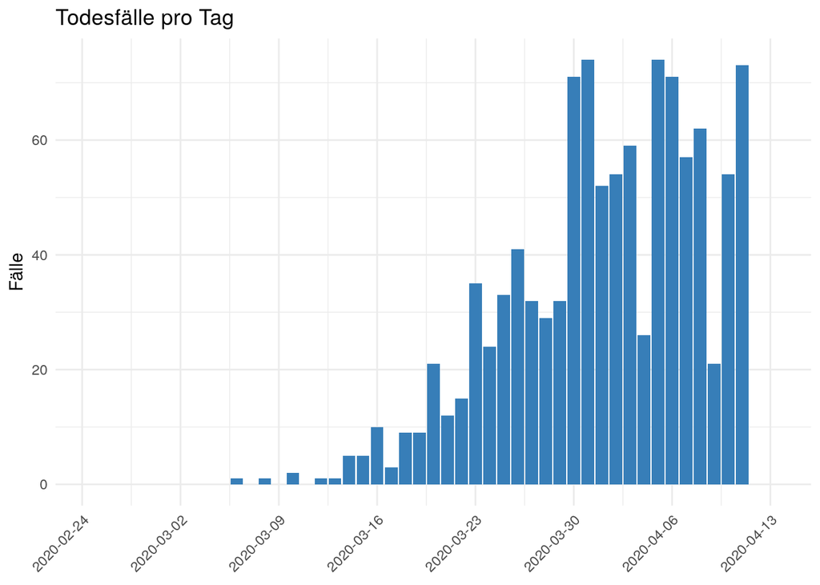

```r
# Balkendiagramm plotten
ggplot(data = new_deceased) +
  # Balkendiagramm definieren
  geom_bar(mapping = aes(x = date, y = new_deceased),
           stat = "identity", fill = "#377eb8") +
  # Theme auswählen
  theme_minimal() +
  # Kein Titel auf der X-Achse
  # Beschriftung der X-Achse um 45° drehen
  theme(axis.title.x = element_blank(),
        axis.text.x = element_text(angle = 45, hjust = 1, vjust = 1)) +
  # Titel und Beschriftung der Y-Achsen anpassen
  labs(title = "Todesfälle pro Tag", y = "Fälle") +
  # Wochen auf X-Achse kennzeichnen
  scale_x_date(date_breaks = '1 week')
```

Anders als bei den Neuinfektionen ist hier leider noch kein rückläufiger Trend erkennbar. Dieser wird sich gegenüber den Neuinfektionen erst mit einigen Tagen oder gar Wochen Verzögerung bemerkbar machen, vorausgesetzt natürlich, dass die Zahl der Neuinfektionen weiter sinkt.

### Situation in den Spitälern

Wie entwickeln sich die Zahlen der hospitalisierten Personen? Wie viele Personen liegen auf der Intensivstation (ICU)? Und wie viele müssen aktuell beatmet werden? Einige Kantone veröffentlichen entsprechende Daten. Welche Kantone sind das?

```r
# Kantone mit genauen Spitaldaten identifizieren
covid_19_raw %>%
  # Relevante Spalten auswählen
  select(canton = abbreviation_canton_and_fl, current_hosp, current_icu, current_vent) %>%
  # Nach Kanton gruppieren
  group_by(canton) %>%
  # Alle Fälle aggregieren
  summarise(hosp = sum(current_hosp),
            icu = sum(current_icu),
            vent = sum(current_vent)) %>%
  # Alle Kantone ausschliessen, die nur NA haben
  filter(!is.na(hosp) | !is.na(icu) | !is.na(vent))
```

```
## # A tibble: 4 x 4
##   canton  hosp   icu  vent
##   <chr>  <dbl> <dbl> <dbl>
## 1 GE      8605  1329  1209
## 2 GR       870    NA    NA
## 3 VD      8323    NA    NA
## 4 VS      2961    NA    NA
```

Wir sehen, dass nur Genf, Graubünden, Waadt und das Wallis genaue Zahlen zur Anzahl hospitalisierter Personen veröffentlichen. Die genausten Angaben macht der Kanton Genf, wo wir sogar Zahlen für die Anzahl beatmeter Personen sowie Personen auf der Intensivstation vorliegen. Konzentrieren wir uns im Folgenden also auf den Kanton Genf und schauen uns an, wie sich die Zahlen über die Zeit entwickelt haben.

```r
# Rohdaten in die richtige Form bringen und aggregieren
hosp_ge_time <- covid_19_raw %>%
  # Nur Daten aus dem Kanton Genf verwenden
  filter(abbreviation_canton_and_fl == "GE") %>%
  # Relevante Spalten auswählen
  select(date, current_hosp, current_icu, current_vent) %>%
  # Vom weiten ins lange Format bringen
  gather(key = "pat", value = "cases", -date)

head(hosp_ge_time)
```

```
## # A tibble: 6 x 3
##   date       pat          cases
##   <date>     <chr>        <dbl>
## 1 2020-02-25 current_hosp     0
## 2 2020-02-26 current_hosp     1
## 3 2020-02-27 current_hosp     1
## 4 2020-02-28 current_hosp     2
## 5 2020-02-29 current_hosp     3
## 6 2020-03-01 current_hosp     3
```

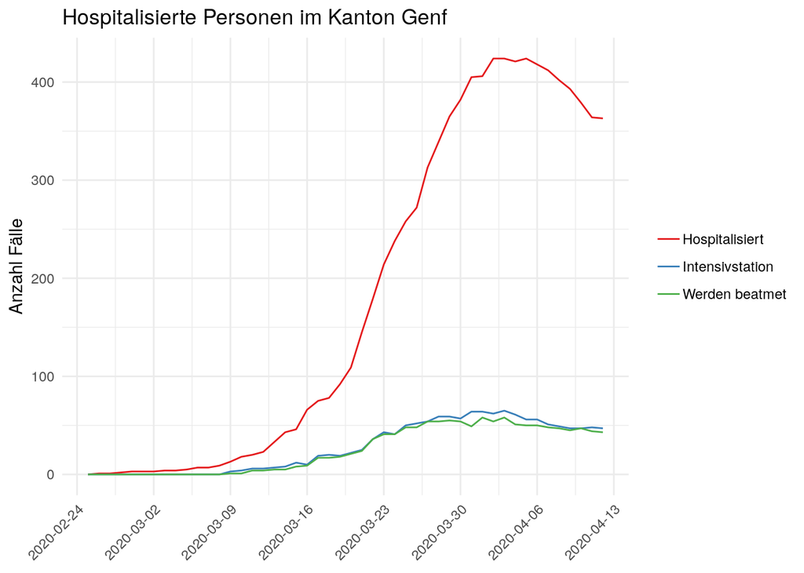

```r
# Liniendiagramm plotten
ggplot(data = hosp_ge_time) +
  # Liniendiagramm definieren
  geom_line(mapping = aes(x = date, y = cases, color = pat)) +
  # Theme auswählen
  theme_minimal() +
  # Kein Titel auf der X-Achse
  # Kein Titel bei der Legende
  # Beschriftung der X-Achse um 45° drehen
  theme(axis.title.x = element_blank(),
        legend.title = element_blank(),
        axis.text.x = element_text(angle = 45, hjust = 1, vjust = 1)) +
  # Titel und Beschriftung der Y-Achsen anpassen
  labs(title = "Hospitalisierte Personen im Kanton Genf", y = "Anzahl Fälle") +
  # Linienfarbe und Beschriftung anpassen
  scale_colour_brewer(palette = "Set1", labels = c("Hospitalisiert", "Intensivstation", "Werden beatmet")) +
  # Wochen auf X-Achse kennzeichnen
  scale_x_date(date_breaks = '1 week')
```

Wir sehen, dass der Kanton Genf bei den hospitalisierten Personen wohl auch über den Berg ist! Aktuell sind es noch ca. 360 Personen, die im Spital gepflegt werden, Anfang April waren es über 400. Was sich allerdings auch zeigt: wenn eine Person auf die Intensivstation muss, dann muss sie meist auch künstlich beatmet werden. Aktuell sind das im Kanton Genf noch immer rund 50 Personen.

### Situation in den Kantonen

Schauen wir uns zum Schluss noch die Entwicklung der Fallzahlen in den Kantonen an. Um diese miteinander vergleichen zu können, müssen wir die Anzahl Corona-Fälle mit der Einwohnerzahl verrechnen. Dafür müssen wir allerdings die Einwohnerzahlen kennen. Als Ausblick auf kommende Sitzungen, scrapen wir uns diese kurzerhand von Wikipedia. Dafür brauchen wir Funktionen aus dem `rvest`-Package.

```r
library(rvest)
```

```r
# Wiki-Page importieren
wiki <- read_html("https://de.wikipedia.org/wiki/Kanton_(Schweiz)")
# Tabelle extrahieren
canton_data <- html_table(wiki, fill = TRUE)[[1]]
#Tabelle anschauen
glimpse(canton_data)
```

```
## Observations: 27
## Variables: 9
## $ Abk.                 <chr> "ZH", "BE", "LU", "UR", "SZ", "OW", "NW", "…
## $ Kanton               <chr> "Kanton Zürich Zürich", "Kanton Bern Bern",…
## $ `Kantons-nummer`     <int> 1, 2, 3, 4, 5, 6, 7, 8, 9, 10, 11, 12, 13, …
## $ `Beitritt`          <chr> "1351", "1353", "1332", "7 1291", "7 1291",…
## $ Hauptort             <chr> "Zürich", "Bern", "Luzern", "Altdorf", "Sch…
## $ `Einwohner1`        <chr> "1'520'968", "1'034'977", "409'557", "36'43…
## $ `Fläche(km²)`        <chr> "1'729", "5'959", "1'493", "1'077", "908", …
## $ `Einwohner-dichte4` <int> 880, 174, 274, 34, 175, 77, 157, 59, 531, 1…
## $ Amtssprache          <chr> "Deutsch", "Deutsch, Französisch", "Deutsch…
```

Die Zahlen haben wir, allerdings liegen sie noch als String vor (mit dem wir nicht rechnen können). Deshalb müssen wir den Data Frame noch etwas umbauen.

```r
pop_data <- canton_data %>%
  # Relevante Spalten auswählen und umbenennen
  select(canton = 1, pop = 6) %>%
  # Tausendertrennzeichen entfernen und zu Zahl umwandeln
  mutate(pop = as.numeric(str_replace_all(pop, "'", "")))

glimpse(pop_data)
```

```
## Observations: 27
## Variables: 2
## $ canton <chr> "ZH", "BE", "LU", "UR", "SZ", "OW", "NW", "GL", "ZG", "FR…
## $ pop    <dbl> 1520968, 1034977, 409557, 36433, 159165, 37841, 43223, 40…
```

Sehr gut, nun können wir die Fallzahlen pro 10’000 Einwohner*innen ausrechnen und uns die Daten im Zeitverlauf anschauen. Konzentrieren wir uns der Übersichtlichkeit zuliebe auf die acht Kantone mit den relativ meisten Fällen.

```r
# Relative Fallzahlen berechnen
cantons_rel <- covid_19_raw %>%
  # Relevante Spalten auswählen
  select(date, canton = abbreviation_canton_and_fl, ncumul_conf) %>%
  # Einwohner*innen-Info zuspielen
  left_join(pop_data, by = "canton") %>%
  # Relative Zahl der Fälle berechnen (pro 10'000 Einwohner*innen)
  mutate(cases_rel = ncumul_conf / (pop / 10000))

# Kantone mit den meisten Fällen pro Kopf identifizieren
cantons_top <- cantons_rel %>%
  # Nur letzter vollständige Tag betrachten
  filter(date == (max(date) - 1)) %>%
  # Relative Fälle absteigend sortieren
  arrange(desc(cases_rel)) %>%
  # Kantone mit den relativ meisten Fällen auswählen (8)
  slice(1:8)

# Daten für Plot vorbereiten
cantons_time <- cantons_rel %>%
  # Nur Daten aus den Kantonen mit den relativ meisten Fällen behalten
  filter(canton %in% cantons_top$canton)

head(cantons_time)
```

```
## # A tibble: 6 x 5
##   date       canton ncumul_conf    pop cases_rel
##   <date>     <chr>        <dbl>  <dbl>     <dbl>
## 1 2020-02-25 GE               0 499480    0
## 2 2020-02-25 TI               1 353343    0.0283
## 3 2020-02-26 GE               1 499480    0.0200
## 4 2020-02-26 TI              NA 353343   NA
## 5 2020-02-27 GE               1 499480    0.0200
## 6 2020-02-27 TI              NA 353343   NA
```

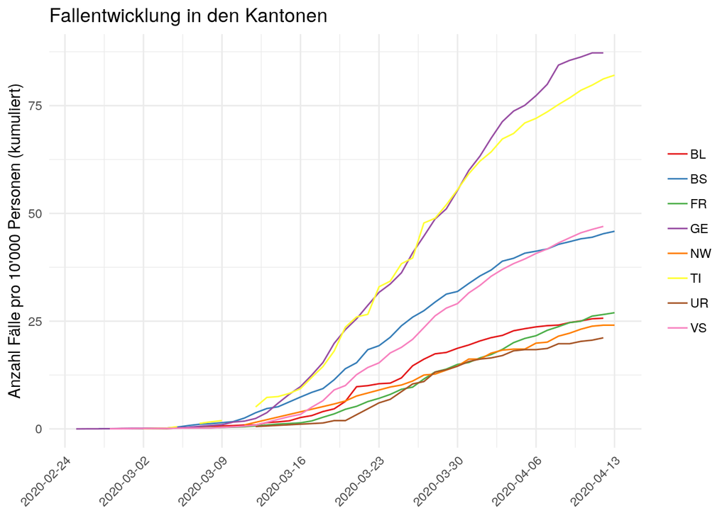

```r
# Liniendiagramm plotten
ggplot(data = cantons_time) +
  # Liniendiagramm definieren
  geom_line(mapping = aes(x = date, y = cases_rel, color = canton)) +
  # Theme auswählen
  theme_minimal() +
  # Kein Titel auf der X-Achse
  # Kein Titel bei der Legende
  # Beschriftung der X-Achse um 45° drehen
  theme(axis.title.x = element_blank(),
        legend.title = element_blank(),
        axis.text.x = element_text(angle = 45, hjust = 1, vjust = 1)) +
  # Titel und Beschriftung der Y-Achsen anpassen
  labs(title = "Fallentwicklung in den Kantonen", y = "Anzahl Fälle pro 10'000 Personen (kumuliert)") +
  # Linienfarbe anpassen
  scale_colour_brewer(palette = "Set1") +
  # Wochen auf X-Achse kennzeichnen
  scale_x_date(date_breaks = '1 week')
```

Die Corona-Hotspots der Schweiz scheinen die Kantone Genf und Tessin sein. In beiden Kantonen gibt inzwischen über 80 Covid-19-Fälle pro 10’000 Einwohner*innen. Bei der Interpretation ist allerdings Vorsicht geboten, denn wir wissen nicht wie viele Personen in den einzelnen Kantonen getestet wurde (nur Genf veröffentlicht entsprechende Zahlen). Gehen wir davon aus, dass in allen Kantonen gleich getestet wird, ist der im Plot angestellte Vergleich zulässig und aussagekräftig. Gehen wir allerdings davon aus, dass die Kantone unterschiedliche Testregimes anwenden, sollten wir die Fallzahlen nicht ohne Weiteres miteinander vergleichen. Auch wenn jüngst einige Kantone von den Testempfehlungen des BAG abweichen ([AZ](https://www.aargauerzeitung.ch/aargau/kanton-aargau/kantonsaerztin-will-tests-fuer-alle-aargauer-mit-corona-symptomen-137610946), [SRF](https://www.srf.ch/news/schweiz/mehr-coronavirus-tests-da-wir-in-zuerich-genuegend-tests-haben-gehen-wir-voran)), können wir aufgrund der Zuteilung der Tests an Spitäler und Labors durch den Bund ([Labor Spiez](https://www.labor-spiez.ch/#Zuteilung)) wohl dennoch von der ersten Situation ausgehen. Ein kantonaler Vergleich scheint also zulässig. Unabhängig davon ist die gute Botschaft des Plots, dass die Kurven auch in den Hotspot-Kantonen derzeit abflachen. Die Situation scheint sich also auch in den am stärksten betroffenen Regionen zu verbessern.